# Mobile Price Classification

*The dataset for this project originates from the [Classify Mobile Price Range](https://www.kaggle.com/iabhishekofficial/mobile-price-classification)*

### Context:

Bob has started his own mobile company. He wants to give tough fight to big companies like Apple,Samsung etc. He does not know how to estimate price of mobiles his company creates. In this competitive mobile phone market you cannot simply assume things. To solve this problem he collects sales data of mobile phones of various companies.

Bob wants to find out some relation between features of a mobile phone(eg:- RAM,Internal Memory etc) and its selling price. But he is not so good at Machine Learning. So he needs your help to solve this problem.

### Problem Statement:

In this problem you do not have to predict actual price but a price range indicating how high the price is

### Attribute Information

The data is contains values of different features of a mobile collected from different sources. The objective is caluclate price range of a mobile.

#### Input variables:

1) **battery_power**: Total energy a battery can store in one time measured in mAh

2) **blue**: Has bluetooth or not

3) **clock_speed**: speed at which microprocessor executes instructions

4) **dual_sim**: Has dual sim support or not

5) **fc**: Front Camera mega pixels

6) **four_g**: Has 4G or not

7) **int_memory**: Internal Memory in Gigabytes

8) **m_dep**: Mobile Depth in cm

9) **mobile_wt**: Weight of mobile phone

10) **n_cores**: Number of cores of processor

11) **pc**: Primary Camera mega pixels

12) **px_height**: Pixel Resolution Height

13) **px_width**: Pixel Resolution Width

14) **ram**: Random Access Memory in Mega Bytes

15) **sc_h**: Screen Height of mobile in cm

16) **sc_w**: Screen Width of mobile in cm

17) **talk_time**: longest time that a single battery charge will last when you are

18) **three_g**: Has 3G or not

19) **touch_screen**: Has touch screen or not

20) **wifi**: Has wifi or not

#### Output variable (desired target):

21) **price_range**: This is the target variable with value of 0 (cheap), 1 (mid priced), 2 (costly) and 3(expensive).

1. **Environment Setup**
   - 1.1 - **Install Package**
   - 1.2 - **Load Dependencies**
2. **Load dataset**
3. **Data Types and Dimensions**
4. **Data Preprocessing**
   - 4.1 - Data Cleaning
   - 4.2 - Exploratory Analysis
     - 4.2.1 - Numeric features
     - 4.2.2 - Categorical features
     - 4.2.3 - Analysis report
   - 4.3 - Feature Selection
   - 4.4 - Data Transformation
     - 4.4.1 - Normalization
     - 4.4.2 - Split the dataset
5. **Model Development**
   - 5.1 - KNN
   - 5.2 - Random Forest
   - 5.3 - Naive Bayes
   - 5.4 - Gradient Boosting
6. **Model Comparision**
7. **Conclusion**

## 1. Environment Setup

goto toc

### 1.1. Install Packages

Install required packages

goto toc

```python
# Install pandas
! pip install pandas

# Install matplotlib
! pip install matplotlib

# Install seaborn
! pip install seaborn

# Install sklearn
! pip install sklearn

# Install tqdm to visualize iterations
! pip install tqdm
```

### 1.2. Load Dependencies

Import required packages

goto toc

```python
# Import libraries necessary for this project
import numpy as np
import pandas as pd
import scipy.stats as stats
import math
from tqdm import tqdm
import matplotlib.pyplot as plt

# Pretty display for notebooks
%matplotlib inline

import seaborn as sns

# Set default setting of seaborn
sns.set()
```

```python
# Import required function for feature selection
from sklearn.feature_selection import SelectKBest
from sklearn.feature_selection import f_classif

# Import the required function for normalization
from sklearn.preprocessing import StandardScaler

# Import train and test split function
from sklearn.model_selection import train_test_split
```

```python
# Import Classifiers to be used

# Import Grid Search Cross Validation for tunning
from sklearn.model_selection import GridSearchCV

# Import KNN classifier
from sklearn.neighbors import KNeighborsClassifier

# Import Random Forest Classifier
from sklearn.ensemble import RandomForestClassifier

# Import Naive bayes classifier
from sklearn.naive_bayes import GaussianNB

# Import KNN classifier
from sklearn.neighbors import KNeighborsClassifier

# Import Gradient Boosting Classifier
from sklearn.ensemble import GradientBoostingClassifier, GradientBoostingRegressor
```

```python
# Import packages to calculate performance of the models
from sklearn import metrics

# Function to compute confusion metric
from sklearn.metrics import confusion_matrix

# Function to generate classification report
from sklearn.metrics import classification_report
```

```python
# To save the model import pickle
import pickle
```

## 2. Load dataset

Read data from mobile_price.csv file using pandas method read_csv().

goto toc

```python
# read the data
raw_data = pd.read_csv('data/mobile_price.csv')

# print the first five rows of the data
raw_data.head()
```

|  | battery_power | blue | clock_speed | dual_sim | fc | four_g | int_memory | m_dep | mobile_wt | n_cores | ... | px_height | px_width | ram | sc_h | sc_w | talk_time | three_g | touch_screen | wifi | price_range |
| --- | --- | --- | --- | --- | --- | --- | --- | --- | --- | --- | --- | --- | --- | --- | --- | --- | --- | --- | --- | --- | --- |
| 0 | 842 | 0 | 2.2 | 0 | 1 | 0 | 7 | 0.6 | 188 | 2 | ... | 20 | 756 | 2549 | 9 | 7 | 19 | 0 | 0 | 1 | 1 |
| 1 | 1021 | 1 | 0.5 | 1 | 0 | 1 | 53 | 0.7 | 136 | 3 | ... | 905 | 1988 | 2631 | 17 | 3 | 7 | 1 | 1 | 0 | 2 |
| 2 | 563 | 1 | 0.5 | 1 | 2 | 1 | 41 | 0.9 | 145 | 5 | ... | 1263 | 1716 | 2603 | 11 | 2 | 9 | 1 | 1 | 0 | 2 |
| 3 | 615 | 1 | 2.5 | 0 | 0 | 0 | 10 | 0.8 | 131 | 6 | ... | 1216 | 1786 | 2769 | 16 | 8 | 11 | 1 | 0 | 0 | 2 |
| 4 | 1821 | 1 | 1.2 | 0 | 13 | 1 | 44 | 0.6 | 141 | 2 | ... | 1208 | 1212 | 1411 | 8 | 2 | 15 | 1 | 1 | 0 | 1 |

5 rows × 21 columns

## 3. Data Types and Dimensions

goto toc

```python
# check the data types of the features
raw_data.info()
```

```
<class 'pandas.core.frame.DataFrame'>
RangeIndex: 2000 entries, 0 to 1999
Data columns (total 21 columns):
 #   Column         Non-Null Count  Dtype
---  ------         --------------  -----
 0   battery_power  2000 non-null   int64
 1   blue           2000 non-null   int64
 2   clock_speed    2000 non-null   float64
 3   dual_sim       2000 non-null   int64
 4   fc             2000 non-null   int64
 5   four_g         2000 non-null   int64
 6   int_memory     2000 non-null   int64
 7   m_dep          2000 non-null   float64
 8   mobile_wt      2000 non-null   int64
 9   n_cores        2000 non-null   int64
 10  pc             2000 non-null   int64
 11  px_height      2000 non-null   int64
 12  px_width       2000 non-null   int64
 13  ram            2000 non-null   int64
 14  sc_h           2000 non-null   int64
 15  sc_w           2000 non-null   int64
 16  talk_time      2000 non-null   int64
 17  three_g        2000 non-null   int64
 18  touch_screen   2000 non-null   int64
 19  wifi           2000 non-null   int64
 20  price_range    2000 non-null   int64
dtypes: float64(2), int64(19)
memory usage: 328.2 KB
```

**Note:**

Features like **blue**, **dual_sim**, **four_g**, **n_cores**, **three_g**, **touch_screen**, **wifi** and **price_range** are actually categorical in nature but are represemted as numeric so we need to convert them for better analysis.

```python
# create copy of the dataframe
data = raw_data.copy()

# Create list of features to be converted into category
features = ['blue', 'dual_sim', 'four_g', 'n_cores', 'three_g', 'touch_screen', 'wifi', 'price_range']

# Convert numeric to categorical
for col in features:
    data[col] = pd.Categorical(data[col])

# Check for datatypes
data.info()
```

```
<class 'pandas.core.frame.DataFrame'>
RangeIndex: 2000 entries, 0 to 1999
Data columns (total 21 columns):
 #   Column         Non-Null Count  Dtype
---  ------         --------------  -----
 0   battery_power  2000 non-null   int64
 1   blue           2000 non-null   category
 2   clock_speed    2000 non-null   float64
 3   dual_sim       2000 non-null   category
 4   fc             2000 non-null   int64
 5   four_g         2000 non-null   category
 6   int_memory     2000 non-null   int64
 7   m_dep          2000 non-null   float64
 8   mobile_wt      2000 non-null   int64
 9   n_cores        2000 non-null   category
 10  pc             2000 non-null   int64
 11  px_height      2000 non-null   int64
 12  px_width       2000 non-null   int64
 13  ram            2000 non-null   int64
 14  sc_h           2000 non-null   int64
 15  sc_w           2000 non-null   int64
 16  talk_time      2000 non-null   int64
 17  three_g        2000 non-null   category
 18  touch_screen   2000 non-null   category
 19  wifi           2000 non-null   category
 20  price_range    2000 non-null   category
dtypes: category(8), float64(2), int64(11)
memory usage: 220.2 KB
```

```python
# Get categorical features
categorical_features = data.select_dtypes('category').columns.values.tolist()

# Get nuemric features
numerical_features = [col for col in data.columns.values if col not in categorical_features]
```

```python
print("Mobile Price Classification Data Set has \033[4m\033[1m{}\033[0m\033[0m data points with \033[4m\033[1m{}\033[0m\033[0m variables each.".format(*raw_data.shape))
print(f"Numeric features: \033[4m\033[1m{len(numerical_features)}\033[0m\033[0m \nCategorical features: \033[4m\033[1m{len(categorical_features)}\033[0m\033[0m")
```

```
Mobile Price Classification Data Set has 2000 data points with 21 variables each.
Numeric features: 13
Categorical features: 8
```

## 4. Data Preprocessing

*Data preprocessing is a data mining technique which is used to transform the raw data in a useful and efficient format.*

...goto toc

## 4.1. Data Cleaning

*Data cleaning* refers to preparing data for analysis by removing or modifying data that is incomplete, irrelevant, duplicated, or improperly formatted.

...goto toc

### Missing Data Treatment

If the missing values are not handled properly we may end up drawing an inaccurate inference about the data. Due to improper handling, the result obtained will differ from the ones where the missing values are present.

```python
# get the count of missing values
missing_values = data.isnull().sum()

# print the count of missing values
print(missing_values)
```

```
battery_power    0
blue             0
clock_speed      0
dual_sim         0
fc               0
four_g           0
int_memory       0
m_dep            0
mobile_wt        0
n_cores          0
pc               0
px_height        0
px_width         0
ram              0
sc_h             0
sc_w             0
talk_time        0
three_g          0
touch_screen     0
wifi             0
price_range      0
dtype: int64
```

**Note: There are no missing values in the dataset so we can proceed further**

### Summary

| Number of Instances | Number of Attributes | Numeric Features | Categorical Features | Missing Values |
| --- | --- | --- | --- | --- |
| 2000 | 21 | 13 | 8 | Null |

## 4.2. Exploratory Analysis

The preliminary analysis of data to discover relationships between measures in the data and to gain an insight on the trends, patterns, and relationships among various entities present in the data set with the help of statistics and visualization tools is called Exploratory Data Analysis (EDA).

Exploratory data analysis is cross-classified in two different ways where each method is either graphical or non-graphical. And then, each method is either univariate, bivariate or multivariate.

...goto toc

### 4.2.1. Numerical Features

*Analysis of only numeric features*

...goto toc

```python
# Get only numeric features for analysis
numeric_data = data[numerical_features]
numeric_data.head()
```

|  | battery_power | clock_speed | fc | int_memory | m_dep | mobile_wt | pc | px_height | px_width | ram | sc_h | sc_w | talk_time |
| --- | --- | --- | --- | --- | --- | --- | --- | --- | --- | --- | --- | --- | --- |
| 0 | 842 | 2.2 | 1 | 7 | 0.6 | 188 | 2 | 20 | 756 | 2549 | 9 | 7 | 19 |
| 1 | 1021 | 0.5 | 0 | 53 | 0.7 | 136 | 6 | 905 | 1988 | 2631 | 17 | 3 | 7 |
| 2 | 563 | 0.5 | 2 | 41 | 0.9 | 145 | 6 | 1263 | 1716 | 2603 | 11 | 2 | 9 |
| 3 | 615 | 2.5 | 0 | 10 | 0.8 | 131 | 9 | 1216 | 1786 | 2769 | 16 | 8 | 11 |
| 4 | 1821 | 1.2 | 13 | 44 | 0.6 | 141 | 14 | 1208 | 1212 | 1411 | 8 | 2 | 15 |

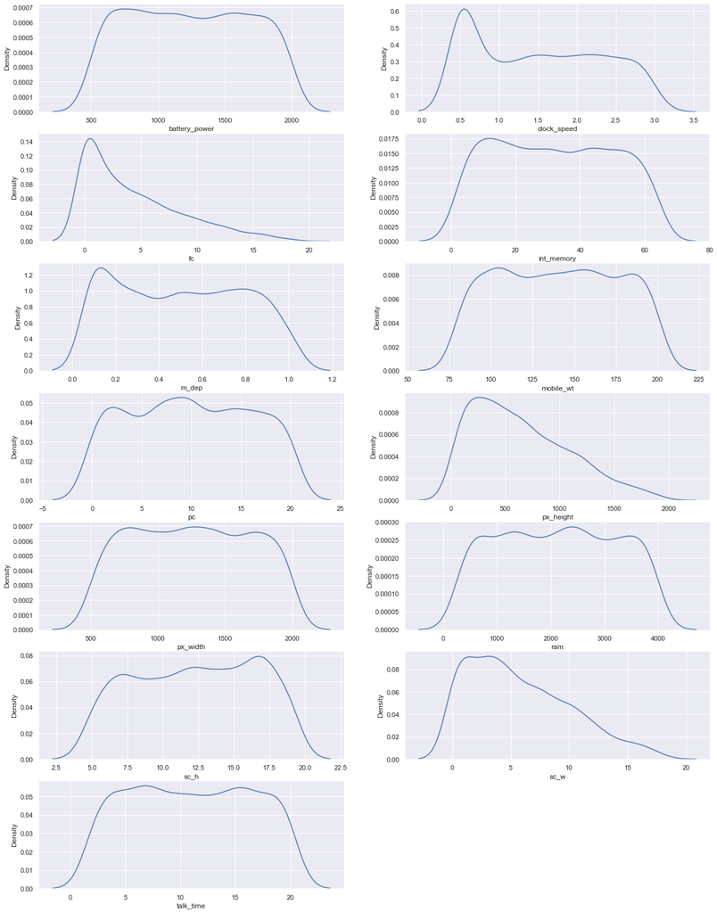

```python
# PLot KDE for all features

# Set size of the figure
plt.figure(figsize=(20,35))

# Iterate on list of features
for i, col in enumerate(numerical_features):
    if numeric_data[col].dtype != 'object':
        ax = plt.subplot(9, 2, i+1)
        kde = sns.kdeplot(numeric_data[col], ax=ax)
        plt.xlabel(col)

# Save the plot
plt.savefig("Numeric_Features_1.png")

# Show plots
plt.show()
```

```python
# Function to plot a numeric feature
def plot_numeric_feature(data, numerical_features):
    # Iterate throw each feature
    for feature in numerical_features:
        print("-"*150)
        print(f"Feature : \033[4m\033[1m{feature}\033[0m\033[0m")
        print("-"*150)

        # Create subplots figure
        fig, axes = plt.subplots(1, 2, figsize=(14, 6))

        # Plot histogram
        sns.histplot(data=data, x=feature, ax = axes[0])

        # Boxplot
        sns.boxplot(y = feature , x = 'price_range', data = data, ax = axes[1] )

        # Displot of given feature with respect to output variable
        sns.displot(data=data, x=feature, hue="price_range", multiple="stack", kind="kde")

        # Save the plot
        fig.savefig(f"{feature}_Feature.png")


        # Show all plots
        plt.show()
```

```
------------------------------------------------------------------------------------------------------------------------------------------------------
Feature : battery_power
------------------------------------------------------------------------------------------------------------------------------------------------------
```

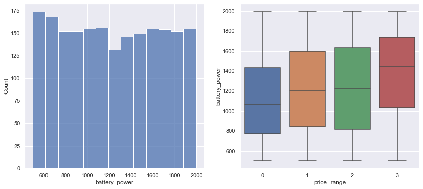

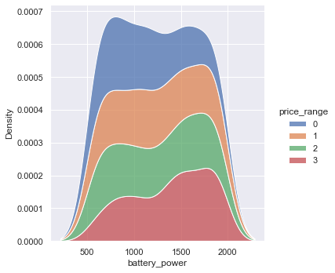

```
------------------------------------------------------------------------------------------------------------------------------------------------------
Feature : clock_speed
------------------------------------------------------------------------------------------------------------------------------------------------------
```

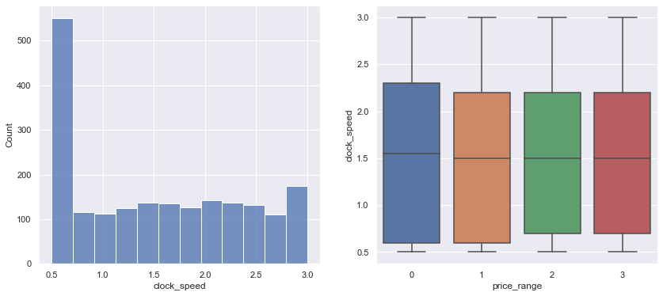

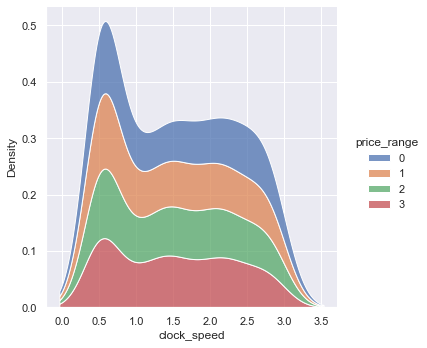

```
------------------------------------------------------------------------------------------------------------------------------------------------------
Feature : fc
------------------------------------------------------------------------------------------------------------------------------------------------------
```

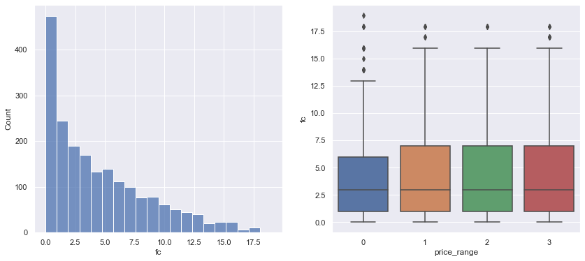

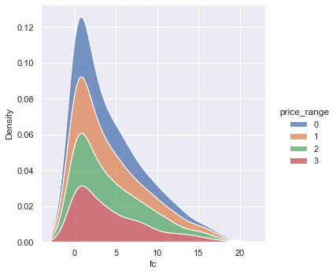

```
------------------------------------------------------------------------------------------------------------------------------------------------------
Feature : int_memory
------------------------------------------------------------------------------------------------------------------------------------------------------
```

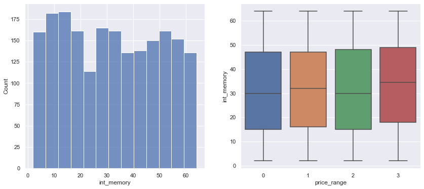

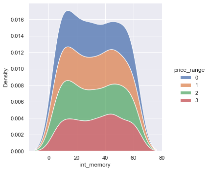

```
------------------------------------------------------------------------------------------------------------------------------------------------------
Feature : m_dep
------------------------------------------------------------------------------------------------------------------------------------------------------
```

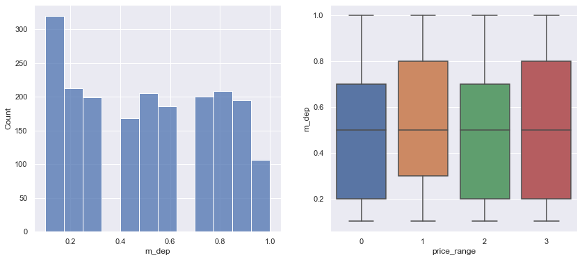

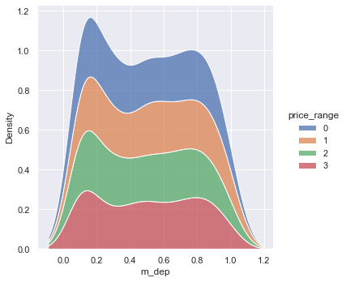

```
------------------------------------------------------------------------------------------------------------------------------------------------------
Feature : mobile_wt
------------------------------------------------------------------------------------------------------------------------------------------------------
```

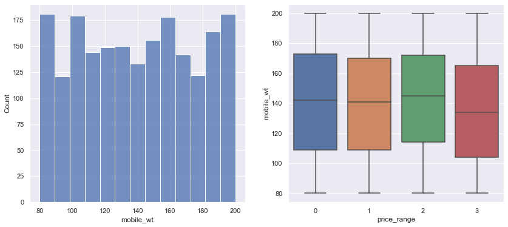

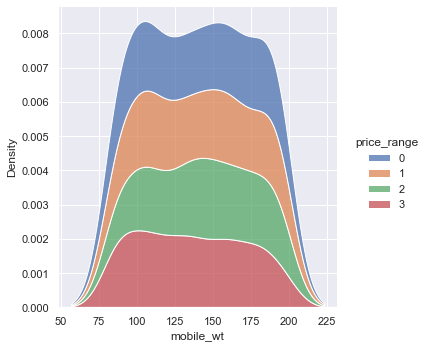

```
------------------------------------------------------------------------------------------------------------------------------------------------------
Feature : pc
------------------------------------------------------------------------------------------------------------------------------------------------------
```

[14 more figures not shown]

```python
plot_numeric_feature(data, numerical_features)
```

**Note:**

- **battery_power**, **int_memory**, **m_depth**, **mobile_wt**, **pc**, **px_width**, **ram**, **sc_h** and **talktime** are features with data concentrated toward the center and their extremes are less in quantity.
- **sc_w**, **px_h**, **fc** and **clock_speed** features are right skewed i.e mean > median > mode

#### Correlation

```python
# check correlation
corr = data.corr(method = 'spearman')
corr
```

|  | battery_power | clock_speed | fc | int_memory | m_dep | mobile_wt | pc | px_height | px_width | ram | sc_h | sc_w | talk_time |
| --- | --- | --- | --- | --- | --- | --- | --- | --- | --- | --- | --- | --- | --- |
| battery_power | 1.000000 | 0.009161 | 0.034931 | -0.003748 | 0.033412 | 0.001752 | 0.030757 | 0.009490 | -0.009040 | -0.001285 | -0.029283 | -0.026544 | 0.052730 |
| clock_speed | 0.009161 | 1.000000 | -0.005288 | 0.005447 | -0.014712 | 0.010773 | -0.005925 | -0.013043 | -0.008619 | 0.004119 | -0.030092 | -0.015129 | -0.012699 |
| fc | 0.034931 | -0.005288 | 1.000000 | -0.027282 | 0.012780 | 0.027134 | 0.659161 | -0.020919 | -0.009170 | 0.019897 | -0.009578 | -0.001169 | -0.001404 |
| int_memory | -0.003748 | 0.005447 | -0.027282 | 1.000000 | 0.007380 | -0.034259 | -0.033373 | -0.001568 | -0.008511 | 0.033061 | 0.040244 | 0.015987 | -0.002436 |
| m_dep | 0.033412 | -0.014712 | 0.012780 | 0.007380 | 1.000000 | 0.022438 | 0.027605 | 0.026156 | 0.023180 | -0.010398 | -0.023964 | -0.019489 | 0.016665 |
| mobile_wt | 0.001752 | 0.010773 | 0.027134 | -0.034259 | 0.022438 | 1.000000 | 0.019011 | 0.011230 | 0.000783 | -0.002731 | -0.033955 | -0.018952 | 0.006343 |
| pc | 0.030757 | -0.005925 | 0.659161 | -0.033373 | 0.027605 | 0.019011 | 1.000000 | -0.015187 | 0.003462 | 0.028860 | 0.005105 | -0.034842 | 0.014256 |
| px_height | 0.009490 | -0.013043 | -0.020919 | -0.001568 | 0.026156 | 0.011230 | -0.015187 | 1.000000 | 0.467538 | -0.030543 | 0.053575 | 0.029327 | -0.010004 |
| px_width | -0.009040 | -0.008619 | -0.009170 | -0.008511 | 0.023180 | 0.000783 | 0.003462 | 0.467538 | 1.000000 | 0.003433 | 0.022846 | 0.025057 | 0.006535 |
| ram | -0.001285 | 0.004119 | 0.019897 | 0.033061 | -0.010398 | -0.002731 | 0.028860 | -0.030543 | 0.003433 | 1.000000 | 0.016473 | 0.026335 | 0.011573 |
| sc_h | -0.029283 | -0.030092 | -0.009578 | 0.040244 | -0.023964 | -0.033955 | 0.005105 | 0.053575 | 0.022846 | 0.016473 | 1.000000 | 0.470398 | -0.017726 |
| sc_w | -0.026544 | -0.015129 | -0.001169 | 0.015987 | -0.019489 | -0.018952 | -0.034842 | 0.029327 | 0.025057 | 0.026335 | 0.470398 | 1.000000 | -0.021530 |
| talk_time | 0.052730 | -0.012699 | -0.001404 | -0.002436 | 0.016665 | 0.006343 | 0.014256 | -0.010004 | 0.006535 | 0.011573 | -0.017726 | -0.021530 | 1.000000 |

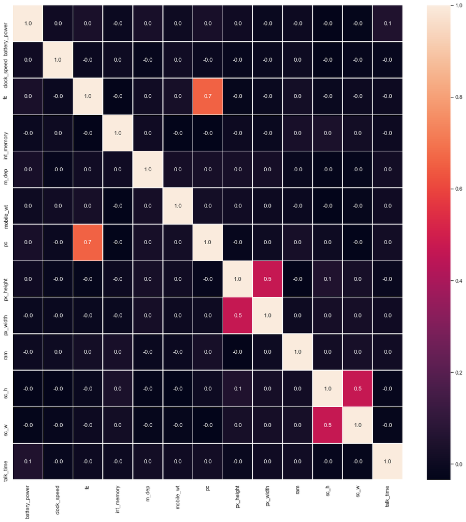

```python
# correlation map
f,ax = plt.subplots(figsize=(18, 18))
sns_plot = sns.heatmap(corr, annot=True, linewidths=.5, fmt= '.1f', ax=ax)

# Save the plot
f.savefig("correlation.png")
```

**Note:** Features **fc**, **pc** are highly correlated

### 4.4.2. Categorical Features

*Analysis of categorical features*

...goto toc

```python
# Get only categorical features for analysis
categorical_data = data[categorical_features]
categorical_data.head()
```

|  | blue | dual_sim | four_g | n_cores | three_g | touch_screen | wifi | price_range |
| --- | --- | --- | --- | --- | --- | --- | --- | --- |
| 0 | 0 | 0 | 0 | 2 | 0 | 0 | 1 | 1 |
| 1 | 1 | 1 | 1 | 3 | 1 | 1 | 0 | 2 |
| 2 | 1 | 1 | 1 | 5 | 1 | 1 | 0 | 2 |
| 3 | 1 | 0 | 0 | 6 | 1 | 0 | 0 | 2 |
| 4 | 1 | 0 | 1 | 2 | 1 | 1 | 0 | 1 |

```python
def plot_categorical_features(data, categorical_features):

    names, count  = {'blue': 'bluetooth', 'dual_sim': "Dual Sim", "four_g":"4G", "n_cores":"No. of Cores",
         "three_g":"3G", "touch_screen":"Touch Screen", "wifi":"WiFi"}, 1

    for feature in categorical_features:

        if feature == "price_range":
            continue

        print("-"*150)
        print(f"Feature : \033[4m\033[1m{names[feature]}\033[0m\033[0m")
        print("-"*150)

        labels = ["no", "yes"] if feature != "n_cores" else data[feature].unique().tolist()

        # Create subplots figure
        fig, axes = plt.subplots(1, 2, figsize=(18, 6))

        if count % 2 == 0:
            # Plot countplot of feature with respect to target
            sns.countplot(x = 'price_range', data = data, hue=feature, ax = axes[0], palette='rainbow')

            # Plot pie chart to show distribution of feature
            axes[1].pie(data[feature].value_counts().values, labels = labels, autopct='%1.1f%%',startangle=90)
            axes[1].set_xlabel(names[feature], size=22)

        else:
            # Plot pie chart to show distribution of feature
            axes[0].pie(data[feature].value_counts().values, labels = labels, autopct='%1.1f%%',startangle=90)
            axes[0].set_xlabel(names[feature], size=22)

            # Plot countplot of feature with respect to target
            sns.countplot(x = 'price_range', data = data, hue=feature, ax = axes[1], palette='rainbow')

        # Increase the counter
        count += 1

        # Save features
        fig.savefig(f"{feature}_feature.png")

        # Show all plots
        plt.show()
```

```
------------------------------------------------------------------------------------------------------------------------------------------------------
Feature : bluetooth
------------------------------------------------------------------------------------------------------------------------------------------------------
```

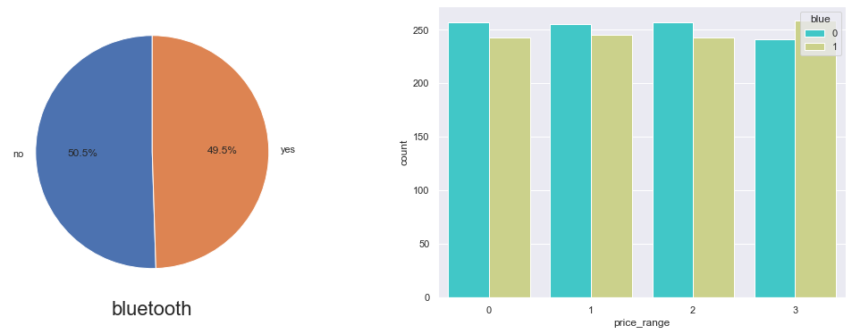

```
------------------------------------------------------------------------------------------------------------------------------------------------------
Feature : Dual Sim
------------------------------------------------------------------------------------------------------------------------------------------------------
```

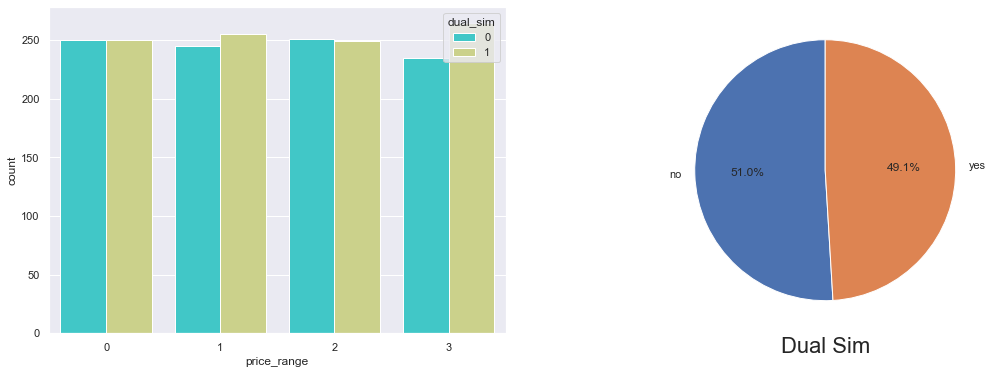

```
------------------------------------------------------------------------------------------------------------------------------------------------------
Feature : 4G
------------------------------------------------------------------------------------------------------------------------------------------------------
```

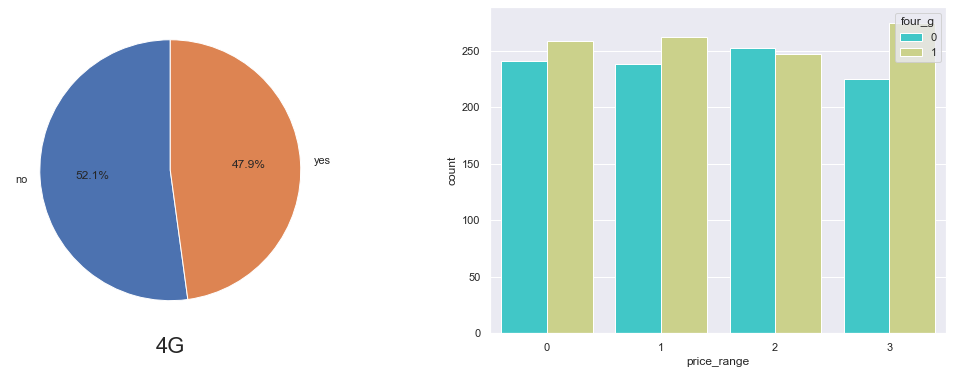

```
------------------------------------------------------------------------------------------------------------------------------------------------------
Feature : No. of Cores
------------------------------------------------------------------------------------------------------------------------------------------------------
```

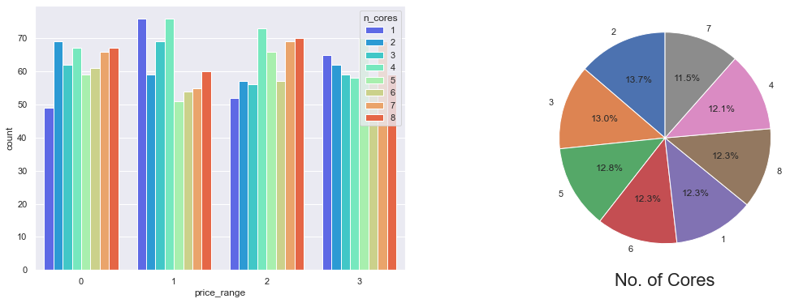

```
------------------------------------------------------------------------------------------------------------------------------------------------------
Feature : 3G
------------------------------------------------------------------------------------------------------------------------------------------------------
```

[figure not shown]

```
------------------------------------------------------------------------------------------------------------------------------------------------------
Feature : Touch Screen
------------------------------------------------------------------------------------------------------------------------------------------------------
```

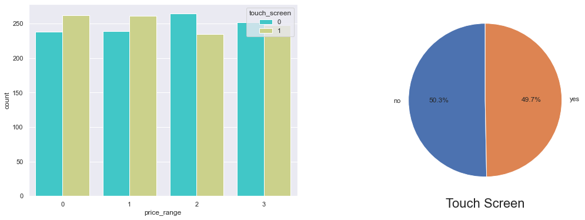

```
------------------------------------------------------------------------------------------------------------------------------------------------------
Feature : WiFi
------------------------------------------------------------------------------------------------------------------------------------------------------
```

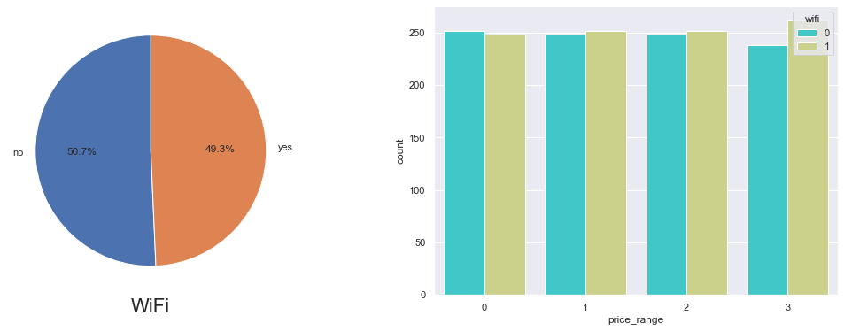

```python
plot_categorical_features(categorical_data, categorical_features)
```

### Analyzing target feature

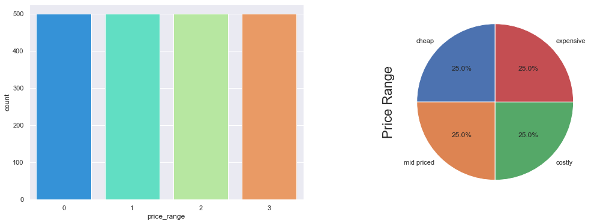

```python
# Create subplots figure
fig, axes = plt.subplots(1, 2, figsize=(18, 6))

# Plot countplot of feature with respect to target
sns.countplot(x = 'price_range', data = data, ax = axes[0], palette='rainbow')

# Plot pie chart to show distribution of feature

labels = ['cheap', 'mid priced', 'costly', 'expensive']

axes[1].pie(categorical_data.price_range.value_counts().values, labels = labels, autopct='%1.1f%%',startangle=90)
axes[1].set_ylabel('Price Range', size=22)

# Save plot
fig.savefig('target_feature.png')

# Show all plots
plt.show()
```

### 4.2.3. Analysis Report

...goto toc

### Analysis Report

| Number of Instances | Number of Attributes | Numeric Features | Categorical Features | Target Feature | Missing Values |
| --- | --- | --- | --- | --- | --- |
| 2000 | 21 | 13 | 8 | price_range | Null |

#### Data Types

| Sr.No. | Column | Data type |
| --- | --- | --- |
| 1 | battery_power | int64 |
| 2 | blue | category |
| 3 | clock_speed | float64 |
| 4 | dual_sim | category |
| 5 | fc | int64 |
| 6 | four_g | category |
| 7 | int_memory | int64 |
| 8 | m_dep | float64 |
| 9 | mobile_wt | int64 |
| 10 | n_cores | category |
| 11 | pc | int64 |
| 12 | px_height | int64 |
| 13 | px_width | int64 |
| 14 | ram | int64 |
| 15 | sc_h | int64 |
| 16 | sc_w | int64 |
| 17 | talk_time | int64 |
| 18 | three_g | category |
| 19 | touch_screen | category |
| 20 | wifi | category |
| 21 | price_range | category |

#### Categorical Features

**Note:**

There is no need to encode categorical features as they are encoded by defualt. We just need to change there datatype using pandas function called *pd.to_numeric()*. But feature **n_cores** need to **one-hot encoded** as it has eight different categories.

```python
# One-hot encode n_cores feature
no_cores = pd.get_dummies(data['n_cores'], prefix='cores', drop_first=True)

# Convert features to numeric
data_preprocessed = data.drop('n_cores', axis = 1).apply(pd.to_numeric, axis = 1)

# Concatenate with original feature
data_preprocessed = data_preprocessed.join(no_cores)
data_preprocessed.head()
```

|  | battery_power | blue | clock_speed | dual_sim | fc | four_g | int_memory | m_dep | mobile_wt | pc | ... | touch_screen | wifi | price_range | cores_2 | cores_3 | cores_4 | cores_5 | cores_6 | cores_7 | cores_8 |
| --- | --- | --- | --- | --- | --- | --- | --- | --- | --- | --- | --- | --- | --- | --- | --- | --- | --- | --- | --- | --- | --- |
| 0 | 842.0 | 0.0 | 2.2 | 0.0 | 1.0 | 0.0 | 7.0 | 0.6 | 188.0 | 2.0 | ... | 0.0 | 1.0 | 1.0 | 1 | 0 | 0 | 0 | 0 | 0 | 0 |
| 1 | 1021.0 | 1.0 | 0.5 | 1.0 | 0.0 | 1.0 | 53.0 | 0.7 | 136.0 | 6.0 | ... | 1.0 | 0.0 | 2.0 | 0 | 1 | 0 | 0 | 0 | 0 | 0 |
| 2 | 563.0 | 1.0 | 0.5 | 1.0 | 2.0 | 1.0 | 41.0 | 0.9 | 145.0 | 6.0 | ... | 1.0 | 0.0 | 2.0 | 0 | 0 | 0 | 1 | 0 | 0 | 0 |
| 3 | 615.0 | 1.0 | 2.5 | 0.0 | 0.0 | 0.0 | 10.0 | 0.8 | 131.0 | 9.0 | ... | 0.0 | 0.0 | 2.0 | 0 | 0 | 0 | 0 | 1 | 0 | 0 |
| 4 | 1821.0 | 1.0 | 1.2 | 0.0 | 13.0 | 1.0 | 44.0 | 0.6 | 141.0 | 14.0 | ... | 1.0 | 0.0 | 1.0 | 1 | 0 | 0 | 0 | 0 | 0 | 0 |

5 rows × 27 columns

## 4.3. Feature Selection

We will be using **f_classif as feature selector** because our **features** are **quantitative** i.e numeric and **target** feature is **categorical**. f_classif is a feature selector that computes the **ANOVA F-value** between each feature and the target vector.

...goto toc

```python
# Seperate independent features and target feature
X, y = data_preprocessed.drop(['price_range'], axis = 1), data_preprocessed['price_range']
```

```python
# Calculate f-score and p-value
f_statistic, p_values = f_classif(X, y)

# Create a dataframe to record score
d = pd.DataFrame()

# Save features
d['feature'] = X.columns

# record F-score
d['fscore'] = f_statistic

# record p-values
d['pvalue'] = p_values

# Sort based of f-score
d.sort_values(by = 'fscore', ascending=False)
```

|  | feature | fscore | pvalue |
| --- | --- | --- | --- |
| 12 | ram | 3520.110824 | 0.000000e+00 |
| 0 | battery_power | 31.598158 | 5.948688e-20 |
| 11 | px_width | 22.620882 | 2.116911e-14 |
| 10 | px_height | 19.484842 | 1.886085e-12 |
| 8 | mobile_wt | 3.594318 | 1.311739e-02 |
| 6 | int_memory | 2.922996 | 3.277694e-02 |
| 13 | sc_h | 2.225984 | 8.324991e-02 |
| 14 | sc_w | 1.671000 | 1.712146e-01 |
| 15 | talk_time | 1.628811 | 1.806686e-01 |
| 7 | m_dep | 1.500682 | 2.124595e-01 |
| 17 | touch_screen | 1.293302 | 2.750433e-01 |
| 22 | cores_5 | 1.291585 | 2.756251e-01 |
| 21 | cores_4 | 1.065282 | 3.626575e-01 |
| 5 | four_g | 1.059525 | 3.651552e-01 |
| 9 | pc | 0.825446 | 4.797489e-01 |
| 24 | cores_7 | 0.784417 | 5.025467e-01 |
| 4 | fc | 0.772182 | 5.095042e-01 |
| 20 | cores_3 | 0.574106 | 6.320524e-01 |
| 25 | cores_8 | 0.513034 | 6.733232e-01 |
| 19 | cores_2 | 0.509003 | 6.760970e-01 |
| 2 | clock_speed | 0.493708 | 6.866752e-01 |
| 1 | blue | 0.476768 | 6.984831e-01 |
| 16 | three_g | 0.457320 | 7.121507e-01 |
| 3 | dual_sim | 0.428239 | 7.327869e-01 |
| 18 | wifi | 0.284940 | 8.363070e-01 |
| 23 | cores_6 | 0.163473 | 9.209778e-01 |

**Note:**

```python
# Perform feature selection we will select best 10 features
fvalue_Best = SelectKBest(f_classif, k = 10)

# Fit and transform feature selector on given dataset
X_best = fvalue_Best.fit_transform(X, y)
```

```python
print(f'Original dataset have \033[4m\033[1m{X.shape[1]}\033[0m\033[0m features.\nAfter feature selection dataset have \033[4m\033[1m{X_best.shape[1]}\033[0m\033[0m features.')
```

```
Original dataset have 26 features.
After feature selection dataset have 10 features.
```

```python
# The list of your K best features
mask = fvalue_Best.get_support()

# Get list of selected features
selected_features = [feature for bool_val, feature in zip(mask, X.columns.values.tolist()) if bool_val]

# print best features
print("Selected features are : ", selected_features)
```

```
Selected features are :  ['battery_power', 'int_memory', 'm_dep', 'mobile_wt', 'px_height', 'px_width', 'ram', 'sc_h', 'sc_w', 'talk_time']
```

## 4.4. Data Transformation

...goto toc

### 4.4.1 Normalization

*Normalization is used to scale the data of an attribute so that it falls in a smaller range, such as -1.0 to 1.0 or 0.0 to 1.0. It is generally useful for classification algorithms.*

We will use *Standard Scaler* to perform normalization.

...goto toc

```python
# Initilize scaler
scaler = StandardScaler()

# fit the scaler
scaler.fit(X_best)
```

```
StandardScaler()
```

```python
# Transform the dataset
X_normal = scaler.fit_transform(X_best)
```

### 4.4.2. Split dataset

We will be splitting the dataset into train and test set with **70-30** split

...goto toc

```python
# let us now split the dataset into train & test
X_train, X_test, y_train, y_test = train_test_split(X_normal, y, test_size = 0.3, random_state=42)

# print the shape of 'x_train'
print("X_train : ",X_train.shape)

# print the shape of 'x_test'
print("X_test : ",X_test.shape)

# print the shape of 'y_train'
print("y_train : ",y_train.shape)

# print the shape of 'y_test'
print("y_test : ",y_test.shape)
```

```
X_train :  (1400, 10)
X_test :  (600, 10)
y_train :  (1400,)
y_test :  (600,)
```

## 5. Model Development

We will be training different classification model and choose the one with best performance

...goto toc

### 5.1. KNN

*To find optimal value of **K** we will be performing hyperparameter tuning using **Grid Search Cross Validation**.*

...goto toc

```python
# Hyperparameter tuning

# Initialize a knn object
knn = KNeighborsClassifier()

# Create a dictionary of all values we want to test for n_neighbors
param_grid = {'n_neighbors': np.arange(2, 6)}
```

```python
# Perform gridsearch
knn_gscv = GridSearchCV(knn, param_grid, cv=5)

# fit the data
knn_gscv.fit(X_train, y_train)
```

```
GridSearchCV(cv=5, estimator=KNeighborsClassifier(),
             param_grid={'n_neighbors': array([2, 3, 4, 5])})
```

```python
# predict the values
y_pred_knn  = knn_gscv.predict(X_test)
```

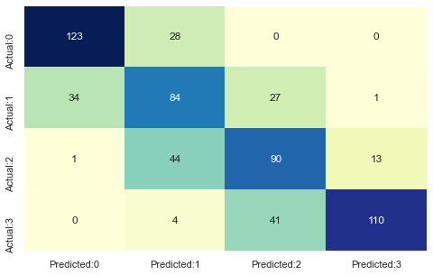

```python
# compute the confusion matrix
cm = confusion_matrix(y_test, y_pred_knn)

# label the confusion matrix
conf_matrix = pd.DataFrame(data=cm,columns=['Predicted:0','Predicted:1','Predicted:2','Predicted:3'],index=['Actual:0','Actual:1','Actual:2','Actual:3'])

# set sizeof the plot
plt.figure(figsize = (8,5))

# plot a heatmap
sns.heatmap(conf_matrix, annot=True, fmt='d', cmap="YlGnBu", cbar=False)
plt.show()
```

```python
# Generate classiffication report

# accuracy measures by classification_report()
result = classification_report(y_test, y_pred_knn)

# print the result
print(result)
```

```
              precision    recall  f1-score   support

         0.0       0.78      0.81      0.80       151
         1.0       0.53      0.58      0.55       146
         2.0       0.57      0.61      0.59       148
         3.0       0.89      0.71      0.79       155

    accuracy                           0.68       600
   macro avg       0.69      0.68      0.68       600
weighted avg       0.69      0.68      0.68       600
```

```python
# Tabulate the result

# create a list of column names
cols = ['Model', 'Precision Score', 'Recall Score','Accuracy Score','f1-score']

# creating an empty dataframe of the colums
result_tabulation = pd.DataFrame(columns = cols)

# compiling the required information
knn_estimator = pd.Series({'Model': "KNN",
                 'Precision Score': metrics.precision_score(y_test, y_pred_knn, average="macro"),
                 'Recall Score': metrics.recall_score(y_test, y_pred_knn, average="macro"),
                 'Accuracy Score': metrics.accuracy_score(y_test, y_pred_knn),
                  'f1-score':metrics.f1_score(y_test, y_pred_knn, average="macro")})



# appending our result table
result_tabulation = result_tabulation.append(knn_estimator , ignore_index = True)

# view the result table
result_tabulation
```

|  | Model | Precision Score | Recall Score | Accuracy Score | f1-score |
| --- | --- | --- | --- | --- | --- |
| 0 | KNN | 0.69005 | 0.676924 | 0.678333 | 0.680475 |

## 5.2 Random Forest

...goto toc

```python
# Fitting Random Forest Classification to the Training set
classifier = RandomForestClassifier(n_estimators = 10, criterion = 'entropy', random_state = 42)
classifier.fit(X_train, y_train)
```

```
RandomForestClassifier(criterion='entropy', n_estimators=10, random_state=42)
```

```python
# Predicting the Test set results
y_pred_random = classifier.predict(X_test)
```

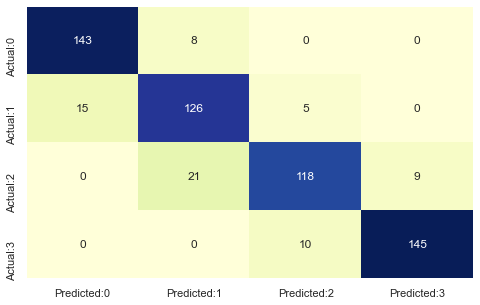

```python
# compute the confusion matrix
cm = confusion_matrix(y_test, y_pred_random)

# label the confusion matrix
conf_matrix = pd.DataFrame(data=cm,columns=['Predicted:0','Predicted:1','Predicted:2','Predicted:3'],index=['Actual:0','Actual:1','Actual:2','Actual:3'])

# set sizeof the plot
plt.figure(figsize = (8,5))

# plot a heatmap
sns.heatmap(conf_matrix, annot=True, fmt='d', cmap="YlGnBu", cbar=False)
plt.show()
```

```python
# Generate classification report

# accuracy measures by classification_report()
result = classification_report(y_test, y_pred_random)

# print the result
print(result)
```

```
              precision    recall  f1-score   support

         0.0       0.91      0.95      0.93       151
         1.0       0.81      0.86      0.84       146
         2.0       0.89      0.80      0.84       148
         3.0       0.94      0.94      0.94       155

    accuracy                           0.89       600
   macro avg       0.89      0.89      0.89       600
weighted avg       0.89      0.89      0.89       600
```

```python
# create the result table for all scores
random_forest_metrics = pd.Series({'Model': "Random Forest",
                 'Precision Score': metrics.precision_score(y_test, y_pred_random, average="macro"),
                 'Recall Score': metrics.recall_score(y_test, y_pred_random, average="macro"),
                 'Accuracy Score': metrics.accuracy_score(y_test, y_pred_random),
                  'f1-score':metrics.f1_score(y_test, y_pred_random, average="macro")})



# appending our result table
result_tabulation = result_tabulation.append(random_forest_metrics , ignore_index = True)

# view the result table
result_tabulation
```

|  | Model | Precision Score | Recall Score | Accuracy Score | f1-score |
| --- | --- | --- | --- | --- | --- |
| 0 | KNN | 0.690050 | 0.676924 | 0.678333 | 0.680475 |
| 1 | Random Forest | 0.886686 | 0.885704 | 0.886667 | 0.885286 |

## 5.3 Naive Bayes

...goto toc

```python
# build the model
GNB = GaussianNB()

# fit the model
GNB.fit(X_train, y_train)
```

```
GaussianNB()
```

```python
# predict the values
y_pred_GNB  = GNB.predict(X_test)
```

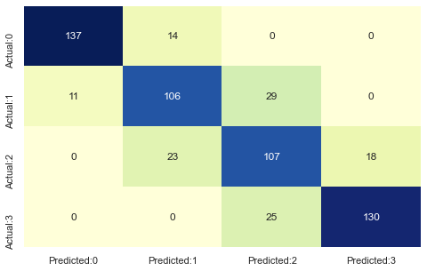

```python
# compute the confusion matrix
cm = confusion_matrix(y_test, y_pred_GNB)

# label the confusion matrix
conf_matrix = pd.DataFrame(data=cm,columns=['Predicted:0','Predicted:1','Predicted:2','Predicted:3'],index=['Actual:0','Actual:1','Actual:2','Actual:3'])

# set sizeof the plot
plt.figure(figsize = (8,5))

# plot a heatmap
sns.heatmap(conf_matrix, annot=True, fmt='d', cmap="YlGnBu", cbar=False)
plt.show()
```

```python
# Generate classiffication report

# accuracy measures by classification_report()
result = classification_report(y_test, y_pred_GNB)

# print the result
print(result)
```

```
              precision    recall  f1-score   support

         0.0       0.93      0.91      0.92       151
         1.0       0.74      0.73      0.73       146
         2.0       0.66      0.72      0.69       148
         3.0       0.88      0.84      0.86       155

    accuracy                           0.80       600
   macro avg       0.80      0.80      0.80       600
weighted avg       0.80      0.80      0.80       600
```

```python
# create the result table for all scores
GNB_metrices = pd.Series({'Model': "Naive Bayes",
                 'Precision Score': metrics.precision_score(y_test, y_pred_GNB, average="macro"),
                 'Recall Score': metrics.recall_score(y_test, y_pred_GNB, average="macro"),
                 'Accuracy Score': metrics.accuracy_score(y_test, y_pred_GNB),
                  'f1-score':metrics.f1_score(y_test, y_pred_GNB, average="macro")})



# appending our result table
result_tabulation = result_tabulation.append(GNB_metrices , ignore_index = True)

# view the result table
result_tabulation
```

|  | Model | Precision Score | Recall Score | Accuracy Score | f1-score |
| --- | --- | --- | --- | --- | --- |
| 0 | KNN | 0.690050 | 0.676924 | 0.678333 | 0.680475 |
| 1 | Random Forest | 0.886686 | 0.885704 | 0.886667 | 0.885286 |
| 2 | Naive Bayes | 0.802477 | 0.798749 | 0.800000 | 0.800149 |

## 5.4 Gradient Boosting

We will be performing hyperparameter tuning

...goto toc

```python
# Choose the best Hyperparameters
# We have chosen, learning_rate, max_depth and the n_estimators.

# Define hyperparameters
parameters = {
    "n_estimators":[5,50,250,500],
    "max_depth":[1,3,5,7,9],
    "learning_rate":[0.01,0.1,1,10,100]
}

# Call the Boosting classifier constructor
gbc = GradientBoostingClassifier()
```

```python
# Use the GridSearhCV() for the cross -validation
cv = GridSearchCV(gbc,parameters,cv=5)

# Fit the data
cv.fit(X_train, y_train)
```

```
GridSearchCV(cv=5, estimator=GradientBoostingClassifier(),
             param_grid={'learning_rate': [0.01, 0.1, 1, 10, 100],
                         'max_depth': [1, 3, 5, 7, 9],
                         'n_estimators': [5, 50, 250, 500]})
```

```python
# Function to display best parameters
def display(results):
    print(f'Best parameters are: {results.best_params_}')
    print("\n")
    mean_score = results.cv_results_['mean_test_score']
    std_score = results.cv_results_['std_test_score']
    params = results.cv_results_['params']
    for mean,std,params in zip(mean_score,std_score,params):
        print(f'{round(mean,3)} + or -{round(std,3)} for the {params}')
```

```python
# Display best parameters
display(cv)
```

```
Best parameters are: {'learning_rate': 1, 'max_depth': 1, 'n_estimators': 500}


0.734 + or -0.026 for the {'learning_rate': 0.01, 'max_depth': 1, 'n_estimators': 5}
0.754 + or -0.023 for the {'learning_rate': 0.01, 'max_depth': 1, 'n_estimators': 50}
0.76 + or -0.032 for the {'learning_rate': 0.01, 'max_depth': 1, 'n_estimators': 250}
0.781 + or -0.024 for the {'learning_rate': 0.01, 'max_depth': 1, 'n_estimators': 500}
0.784 + or -0.024 for the {'learning_rate': 0.01, 'max_depth': 3, 'n_estimators': 5}
0.794 + or -0.023 for the {'learning_rate': 0.01, 'max_depth': 3, 'n_estimators': 50}
0.836 + or -0.019 for the {'learning_rate': 0.01, 'max_depth': 3, 'n_estimators': 250}
0.876 + or -0.011 for the {'learning_rate': 0.01, 'max_depth': 3, 'n_estimators': 500}
0.841 + or -0.018 for the {'learning_rate': 0.01, 'max_depth': 5, 'n_estimators': 5}
0.857 + or -0.009 for the {'learning_rate': 0.01, 'max_depth': 5, 'n_estimators': 50}
0.879 + or -0.016 for the {'learning_rate': 0.01, 'max_depth': 5, 'n_estimators': 250}
0.885 + or -0.014 for the {'learning_rate': 0.01, 'max_depth': 5, 'n_estimators': 500}
0.834 + or -0.02 for the {'learning_rate': 0.01, 'max_depth': 7, 'n_estimators': 5}
0.846 + or -0.019 for the {'learning_rate': 0.01, 'max_depth': 7, 'n_estimators': 50}
0.868 + or -0.026 for the {'learning_rate': 0.01, 'max_depth': 7, 'n_estimators': 250}
0.877 + or -0.021 for the {'learning_rate': 0.01, 'max_depth': 7, 'n_estimators': 500}
0.824 + or -0.022 for the {'learning_rate': 0.01, 'max_depth': 9, 'n_estimators': 5}
0.832 + or -0.021 for the {'learning_rate': 0.01, 'max_depth': 9, 'n_estimators': 50}
0.852 + or -0.02 for the {'learning_rate': 0.01, 'max_depth': 9, 'n_estimators': 250}
0.86 + or -0.025 for the {'learning_rate': 0.01, 'max_depth': 9, 'n_estimators': 500}
0.754 + or -0.023 for the {'learning_rate': 0.1, 'max_depth': 1, 'n_estimators': 5}
0.781 + or -0.024 for the {'learning_rate': 0.1, 'max_depth': 1, 'n_estimators': 50}
0.871 + or -0.014 for the {'learning_rate': 0.1, 'max_depth': 1, 'n_estimators': 250}
0.901 + or -0.01 for the {'learning_rate': 0.1, 'max_depth': 1, 'n_estimators': 500}
0.792 + or -0.025 for the {'learning_rate': 0.1, 'max_depth': 3, 'n_estimators': 5}
0.88 + or -0.007 for the {'learning_rate': 0.1, 'max_depth': 3, 'n_estimators': 50}
0.894 + or -0.012 for the {'learning_rate': 0.1, 'max_depth': 3, 'n_estimators': 250}
0.897 + or -0.013 for the {'learning_rate': 0.1, 'max_depth': 3, 'n_estimators': 500}
0.852 + or -0.004 for the {'learning_rate': 0.1, 'max_depth': 5, 'n_estimators': 5}
0.889 + or -0.012 for the {'learning_rate': 0.1, 'max_depth': 5, 'n_estimators': 50}
0.899 + or -0.014 for the {'learning_rate': 0.1, 'max_depth': 5, 'n_estimators': 250}
0.896 + or -0.015 for the {'learning_rate': 0.1, 'max_depth': 5, 'n_estimators': 500}
0.842 + or -0.021 for the {'learning_rate': 0.1, 'max_depth': 7, 'n_estimators': 5}
0.88 + or -0.017 for the {'learning_rate': 0.1, 'max_depth': 7, 'n_estimators': 50}
0.892 + or -0.02 for the {'learning_rate': 0.1, 'max_depth': 7, 'n_estimators': 250}
0.895 + or -0.016 for the {'learning_rate': 0.1, 'max_depth': 7, 'n_estimators': 500}
0.834 + or -0.022 for the {'learning_rate': 0.1, 'max_depth': 9, 'n_estimators': 5}
```

[output cut: 48 more lines]

```
0.177 + or -0.08 for the {'learning_rate': 100, 'max_depth': 3, 'n_estimators': 50}
0.177 + or -0.08 for the {'learning_rate': 100, 'max_depth': 3, 'n_estimators': 250}
0.176 + or -0.08 for the {'learning_rate': 100, 'max_depth': 3, 'n_estimators': 500}
0.289 + or -0.106 for the {'learning_rate': 100, 'max_depth': 5, 'n_estimators': 5}
0.335 + or -0.12 for the {'learning_rate': 100, 'max_depth': 5, 'n_estimators': 50}
0.289 + or -0.098 for the {'learning_rate': 100, 'max_depth': 5, 'n_estimators': 250}
0.31 + or -0.13 for the {'learning_rate': 100, 'max_depth': 5, 'n_estimators': 500}
0.64 + or -0.186 for the {'learning_rate': 100, 'max_depth': 7, 'n_estimators': 5}
0.501 + or -0.228 for the {'learning_rate': 100, 'max_depth': 7, 'n_estimators': 50}
0.584 + or -0.183 for the {'learning_rate': 100, 'max_depth': 7, 'n_estimators': 250}
0.538 + or -0.211 for the {'learning_rate': 100, 'max_depth': 7, 'n_estimators': 500}
0.794 + or -0.072 for the {'learning_rate': 100, 'max_depth': 9, 'n_estimators': 5}
0.786 + or -0.052 for the {'learning_rate': 100, 'max_depth': 9, 'n_estimators': 50}
0.721 + or -0.185 for the {'learning_rate': 100, 'max_depth': 9, 'n_estimators': 250}
0.775 + or -0.08 for the {'learning_rate': 100, 'max_depth': 9, 'n_estimators': 500}
```

**Note:**

Best parameters are:

- learning_rate = 1
- max_depth = 1
- n_estimators = 500

```python
# Train the classifier
GBM = GradientBoostingClassifier(learning_rate=1, max_depth=1, n_estimators=500)

# fit on data
GBM.fit(X_train, y_train)
```

```
GradientBoostingClassifier(learning_rate=1, max_depth=1, n_estimators=500)
```

```python
# Create a dataframe to store importance of features
feature_importance = pd.DataFrame()
feature_importance['feature'] = selected_features
feature_importance['Importance'] = GBM.feature_importances_

# Sort in decreasing order
feature_importance = feature_importance.sort_values(ascending = False, by = 'Importance').reset_index(drop=True)
feature_importance
```

|  | feature | Importance |
| --- | --- | --- |
| 0 | ram | 0.881613 |
| 1 | battery_power | 0.057333 |
| 2 | px_height | 0.025328 |
| 3 | px_width | 0.022853 |
| 4 | int_memory | 0.005798 |
| 5 | mobile_wt | 0.003682 |
| 6 | m_dep | 0.001509 |
| 7 | sc_w | 0.001049 |
| 8 | talk_time | 0.000602 |
| 9 | sc_h | 0.000232 |

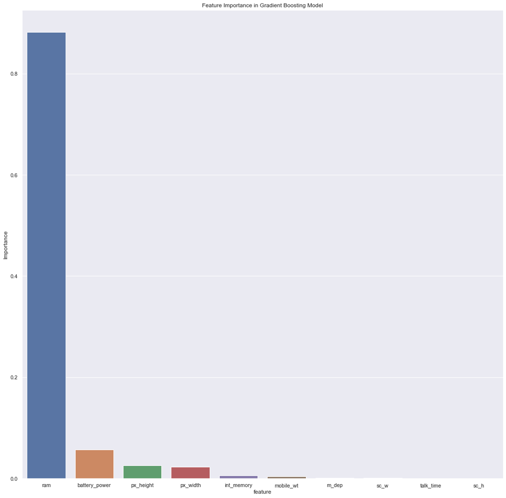

```python
# Plot feature importance
fig, ax = plt.subplots(figsize = (18,18))

# Barplot
sns.barplot(x = 'feature' , y = 'Importance', data = feature_importance, ax = ax)

# Add title
ax.set_title("Feature Importance in Gradient Boosting Model")

# Save the plot
fig.savefig('Feature_importance.png')

# Show the plot
plt.show()
```

```python
# predict the values
y_pred_gbm  = GBM.predict(X_test)
```

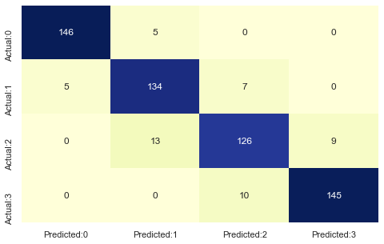

```python
# compute the confusion matrix
cm = confusion_matrix(y_test, y_pred_gbm)

# label the confusion matrix
conf_matrix = pd.DataFrame(data=cm,columns=['Predicted:0','Predicted:1','Predicted:2','Predicted:3'],index=['Actual:0','Actual:1','Actual:2','Actual:3'])

# set sizeof the plot
plt.figure(figsize = (8,5))

# plot a heatmap
sns.heatmap(conf_matrix, annot=True, fmt='d', cmap="YlGnBu", cbar=False)
plt.show()
```

```python
# Generate classification report

# accuracy measures by classification_report()
result = classification_report(y_test, y_pred_gbm)

# print the result
print(result)
```

```
              precision    recall  f1-score   support

         0.0       0.97      0.97      0.97       151
         1.0       0.88      0.92      0.90       146
         2.0       0.88      0.85      0.87       148
         3.0       0.94      0.94      0.94       155

    accuracy                           0.92       600
   macro avg       0.92      0.92      0.92       600
weighted avg       0.92      0.92      0.92       600
```

```python
# create the result table for all scores
GBM_metrices = pd.Series({'Model': "Gradient Boosting",
                 'Precision Score': metrics.precision_score(y_test, y_pred_gbm, average="macro"),
                 'Recall Score': metrics.recall_score(y_test, y_pred_gbm, average="macro"),
                 'Accuracy Score': metrics.accuracy_score(y_test, y_pred_gbm),
                  'f1-score':metrics.f1_score(y_test, y_pred_gbm, average="macro")})



# appending our result table
result_tabulation = result_tabulation.append(GBM_metrices , ignore_index = True)

# view the result table
result_tabulation
```

|  | Model | Precision Score | Recall Score | Accuracy Score | f1-score |
| --- | --- | --- | --- | --- | --- |
| 0 | KNN | 0.690050 | 0.676924 | 0.678333 | 0.680475 |
| 1 | Random Forest | 0.886686 | 0.885704 | 0.886667 | 0.885286 |
| 2 | Naive Bayes | 0.802477 | 0.798749 | 0.800000 | 0.800149 |
| 3 | Gradient Boosting | 0.917786 | 0.917883 | 0.918333 | 0.917677 |

## 6. Model Comparision

...goto toc

```python
result_tabulation
```

|  | Model | Precision Score | Recall Score | Accuracy Score | f1-score |
| --- | --- | --- | --- | --- | --- |
| 0 | KNN | 0.690050 | 0.676924 | 0.678333 | 0.680475 |
| 1 | Random Forest | 0.886686 | 0.885704 | 0.886667 | 0.885286 |
| 2 | Naive Bayes | 0.802477 | 0.798749 | 0.800000 | 0.800149 |
| 3 | Gradient Boosting | 0.917786 | 0.917883 | 0.918333 | 0.917677 |

**Note: We can see that Gradient Boosting Method has outperformed.**

```python
best_model = GBM
```

### Save the model

```python
pickle.dump(best_model, open("mobile_price_predictor.sav", "wb"))
```

...goto toc

### Conclusion

During the analysis the given problem of predicting the price range we found that the problem is a multiclass classiffication problem and the dataset given is balanced with respect different categories of target feature (price_range).

We built different classifier for the given problem like KNN, Naive Bayes, Random Forest but **Gradient Boosting Classifier** outperformed other classifiers with test accuracy of **91.8%** and a f1-score of **0.917**.

Additionaly, while extracting feature importance from trained gradient boosting classifier we found that the feature **RAM** is the most important feature to predict price among all the features which is also true in practical scenario.

#### Best Model

| Model | Precision Score | Recall Score | Accuracy Score | f1-score |
| --- | --- | --- | --- | --- |
| Gradient Boosting | 0.917786 | 0.917883 | 0.918333 | 0.917677 |